## set up the working directory for the task

```r
folder = 'C:/Users/אחיעד/Desktop/data science/ass3/question1_part1'
setwd(folder)

#Or for all chuncks in this Rmarkdown:
knitr::opts_knit$set(root.dir = folder)
```

## install and import the igraph package in order to create a graph for the grey anatomy data set.

```r
#install.packages("igraph")
library(igraph)
```

## read the grey anatomy data set and create a graph from it using the igraph package.

```r
ga.data <- read.csv('ga_edgelist.csv', header = T)
g <- graph.data.frame(ga.data,directed = F)
```

## compute the degree of each node in the graph , and print the graph using the degree of each node to see which nodes are the most connected in the graph.

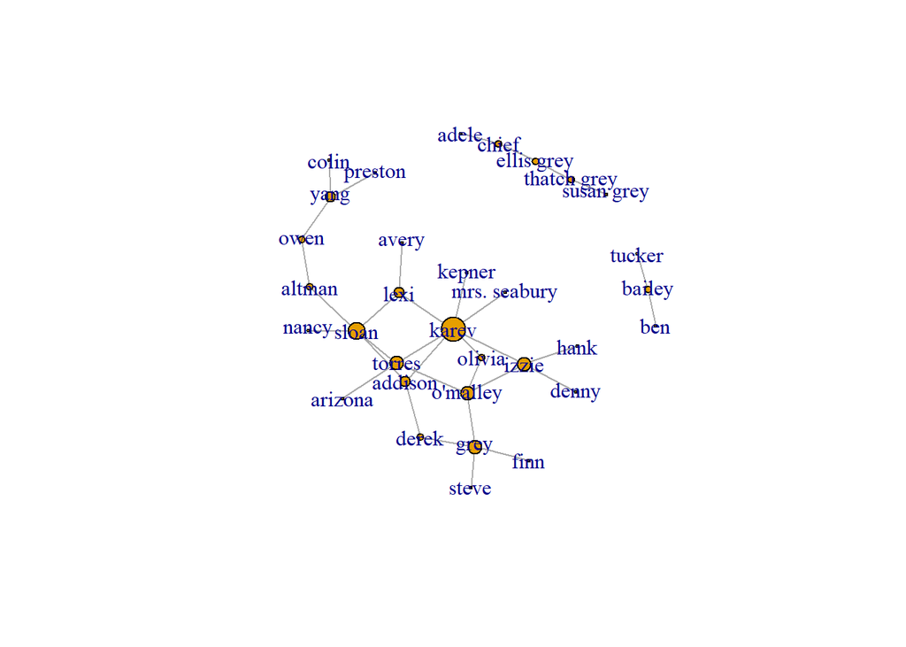

```r
degr.score <- degree(g)
V(g)$size <- degr.score * 2 # multiply by 2 for scale
plot(g)
```

## compute the component of the graph in order to delete the nodes that are not part of the giant component of the graph. (you asked us to work on the giant component of the graph).

```r
clu <- components(g)
groups(clu)
```

```
## $`1`
##  [1] "lexi"         "owen"         "sloan"        "torres"
##  [5] "derek"        "karev"        "o'malley"     "yang"
##  [9] "grey"         "izzie"        "altman"       "arizona"
## [13] "colin"        "preston"      "kepner"       "addison"
## [17] "nancy"        "olivia"       "mrs. seabury" "hank"
## [21] "denny"        "finn"         "steve"        "avery"
##
## $`2`
## [1] "chief"       "ellis grey"  "susan grey"  "adele"       "thatch grey"
##
## $`3`
## [1] "bailey" "tucker" "ben"
```

## delete the nodes that are not part of the giant component of the graph.

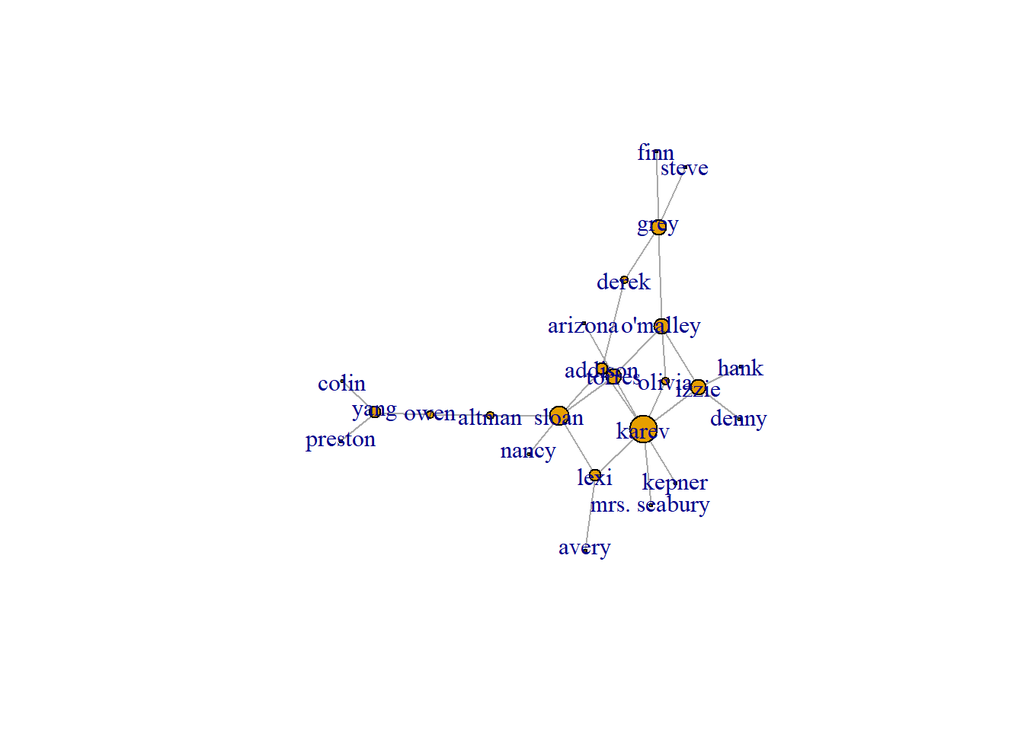

```r
g_<-delete.vertices(g, c("chief", "ellis grey" , "susan grey" , "adele" , "thatch grey","bailey", "tucker", "ben"))
plot(g_)
```

## compute the betweeness of each node in the giant component of the graph. We use the betweeness algorhitm with igraph package on the g_ graph which includes only the giant component of the graph. the graph is not directed and he has no weights on the edges. The nobigint is set to TRUE in order to not use big integers in the calculation because This is only required for lattice-like graphs that have very many shortest paths between a pair of vertices.We also set the normalized parameter to false because we dont want to normalize the results.

# The highest betweeness that measured is for the actor : sloan.

```r
betweenness(g_, v = V(g_), directed = FALSE, weights = NULL,
  nobigint = TRUE, normalized = FALSE)
```

```
##         lexi         owen        sloan       torres        derek
##     36.00000     60.00000    115.36667     67.15000     17.95000
##        karev     o'malley         yang         grey        izzie
##     95.26667     54.41667     43.00000     46.86667     47.95000
##       altman      arizona        colin      preston       kepner
##     76.00000      0.00000      0.00000      0.00000      0.00000
##      addison        nancy       olivia mrs. seabury         hank
##     44.08333      0.00000      4.95000      0.00000      0.00000
##        denny         finn        steve        avery
##      0.00000      0.00000      0.00000      0.00000
```

## compute the closeness of each node in the giant component of the graph. We use the closeness algorhitm with igraph package on the g_ graph which includes only the giant component of the graph. the graph has no weights on the edges. We also set the normalized parameter to false because we dont want to normalize the results.

# The highest closeness that measured is for the actor : torres.

```r
closeness(g_, vids = V(g_),   weights = NULL, normalized = FALSE)
```

```
##         lexi         owen        sloan       torres        derek
##  0.015384615  0.011235955  0.016949153  0.017543860  0.013698630
##        karev     o'malley         yang         grey        izzie
##  0.016949153  0.015873016  0.009345794  0.012987013  0.014492754
##       altman      arizona        colin      preston       kepner
##  0.013698630  0.012658228  0.007751938  0.007751938  0.012345679
##      addison        nancy       olivia mrs. seabury         hank
##  0.016949153  0.012345679  0.013698630  0.012345679  0.010989011
##        denny         finn        steve        avery
##  0.010989011  0.010101010  0.010101010  0.011494253
```

## compute the iii. Eigenvector of each node in the giant component of the graph. We use the eigen_centrality algorhitm with igraph package on the g_ graph which includes only the giant component of the graph. the graph is not directed and he has no weights on the edges. scale is Logical scalar, whether to scale the result to have a maximum score of one (we want to see which actor has the maximal Eigenvector. the options is A named list, to override some ARPACK options.

# The highest Eigenvector that measured is for the actor : karev.

```r
eigen_centrality(g_, directed = FALSE, scale = TRUE, weights = NULL,
  options = arpack_defaults)
```

```
## $vector
##         lexi         owen        sloan       torres        derek
##  0.525580626  0.067803814  0.641812107  0.717877288  0.250030245
##        karev     o'malley         yang         grey        izzie
##  1.000000000  0.600697535  0.023949556  0.300492721  0.565395852
##       altman      arizona        colin      preston       kepner
##  0.207702396  0.210120473  0.007009961  0.007009961  0.292696923
##      addison        nancy       olivia mrs. seabury         hank
##  0.553736435  0.187856429  0.468519243  0.292696923  0.165489626
##        denny         finn        steve        avery
##  0.165489626  0.087953295  0.087953295  0.153835832
##
## $value
## [1] 3.416503
##
## $options
## $options$bmat
## [1] "I"
##
## $options$n
## [1] 24
##
## $options$which
## [1] "LA"
##
## $options$nev
## [1] 1
##
## $options$tol
## [1] 0
##
## $options$ncv
## [1] 0
##
## $options$ldv
## [1] 0
##
## $options$ishift
## [1] 1
##
```

[output cut: 20 more lines]

[output not shown]